# Assignment 3

Marissa Getts

9/21/2020

For all possible pairs of variables in your dataset, test the relationship between the two variables. Indicate the significance and (if appropriate) the magnitude of each relationship. As you work on this assignment, you may find that you’ve changed your mind about which variables you want to include in your dataset or how you want to define them. That’s not a problem; you can change your dataset at any time. Clearly indicate how you’ve decided to change it and why.

Here’s my dataset for this assignment - I pared down my data set to the following variables after spending too much time trying to manage hitting all the variables.

*Categorical:*

1. ACCESS - access to internet
2. LAPTOP - laptop or desktop
3. SMARTPHONE - smartphone

*Continuous:*

1. HINCP - household income past 12 months
2. BDSP - bedrooms per household
3. NP - number of persons per household
4. NOC - number of own children

*run correlations for the following combinations:* **continuous/continuous**

1. HINCP + BDSP
2. HINCP + NP
3. HINCP + NOC
4. BDSP + NP
5. BDSP + NOC
6. NP + NOC

**continuous/categorical**

1. HINCP + LAPTOP
2. HINCP + SMARTPHONE
3. HINCP + ACCESS
4. BDSP + LAPTOP
5. BDSP + SMARTPHONE
6. BDSP + ACCESS
7. NP + LAPTOP
8. NP + SMARTPHONE
9. NP + ACCESS
10. NOC + LAPTOP
11. NOC + SMARTPHONE
12. NOC + ACCESS

**categorical/categorical**

1. ACCESS + LAPTOP
2. ACCESS + SMARTPHONE
3. LAPTOP + SMARTPHONE

**continuous/continuous**  
Based on the p-values, the correlations’ strength and statistical significance are as follows:

```r
correlation1 <- cor.test(hh_data$HINCP, hh_data$BDSP)

correlation1
```

```
##
##  Pearson's product-moment correlation
##
## data:  hh_data$HINCP and hh_data$BDSP
## t = 65.406, df = 30320, p-value < 2.2e-16
## alternative hypothesis: true correlation is not equal to 0
## 95 percent confidence interval:
##  0.3417345 0.3614627
## sample estimates:
##       cor
## 0.3516376
```

```r
correlation2 <- cor.test(hh_data$HINCP, hh_data$NP)

correlation2
```

```
##
##  Pearson's product-moment correlation
##
## data:  hh_data$HINCP and hh_data$NP
## t = 32.08, df = 30320, p-value < 2.2e-16
## alternative hypothesis: true correlation is not equal to 0
## 95 percent confidence interval:
##  0.1702739 0.1920464
## sample estimates:
##       cor
## 0.1811824
```

```r
correlation3 <- cor.test(hh_data$HINCP, hh_data$NOC)

correlation3
```

```
##
##  Pearson's product-moment correlation
##
## data:  hh_data$HINCP and hh_data$NOC
## t = 6.7849, df = 30320, p-value = 1.183e-11
## alternative hypothesis: true correlation is not equal to 0
## 95 percent confidence interval:
##  0.02769203 0.05016930
## sample estimates:
##        cor
## 0.03893559
```

```r
correlation4 <- cor.test(hh_data$BDSP, hh_data$NP)

correlation4
```

```
##
##  Pearson's product-moment correlation
##
## data:  hh_data$BDSP and hh_data$NP
## t = 78.929, df = 30320, p-value < 2.2e-16
## alternative hypothesis: true correlation is not equal to 0
## 95 percent confidence interval:
##  0.4034729 0.4221477
## sample estimates:
##       cor
## 0.4128537
```

```r
correlation5 <- cor.test(hh_data$BDSP, hh_data$NOC)

correlation5
```

```
##
##  Pearson's product-moment correlation
##
## data:  hh_data$BDSP and hh_data$NOC
## t = 54.988, df = 30320, p-value < 2.2e-16
## alternative hypothesis: true correlation is not equal to 0
## 95 percent confidence interval:
##  0.2908639 0.3113342
## sample estimates:
##       cor
## 0.3011338
```

```r
correlation6 <- cor.test(hh_data$NP, hh_data$NOC)

correlation6
```

```
##
##  Pearson's product-moment correlation
##
## data:  hh_data$NP and hh_data$NOC
## t = 182.5, df = 30320, p-value < 2.2e-16
## alternative hypothesis: true correlation is not equal to 0
## 95 percent confidence interval:
##  0.7180939 0.7288223
## sample estimates:
##       cor
## 0.7235018
```

Here is a graph showing the relationship between variables HINCP and NP.

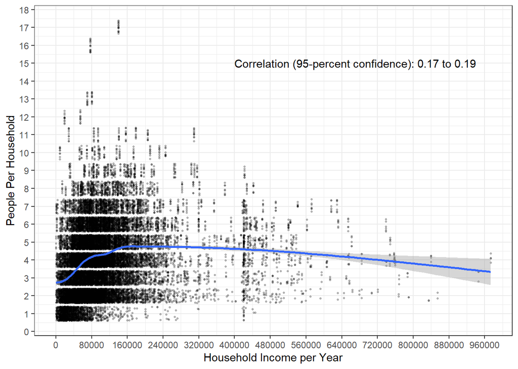

```r
ggplot(hh_data, aes(x = HINCP, y = NP)) +
  geom_point(size = 0.5, alpha = 0.25, position = "jitter") +
  geom_smooth() +
  theme_bw() +
  scale_x_continuous(name = "Household Income per Year",
                     breaks = seq(0,1000000, by = 80000)) +
  scale_y_continuous(name = "People Per Household",
                     breaks = seq(0, 18, by = 1)) +
  annotate(geom = "text", x = 400000, y = 15,
           label = paste("Correlation (95-percent confidence):",
                         prettyNum(correlationHINCPNP$conf.int[1], digits = 2),
                         "to",
                        prettyNum(correlationHINCPNP$conf.int[2], digits = 2)),
           hjust = 0)
```

Here is a graph showing the relationship between variables HINCP and BDSP.

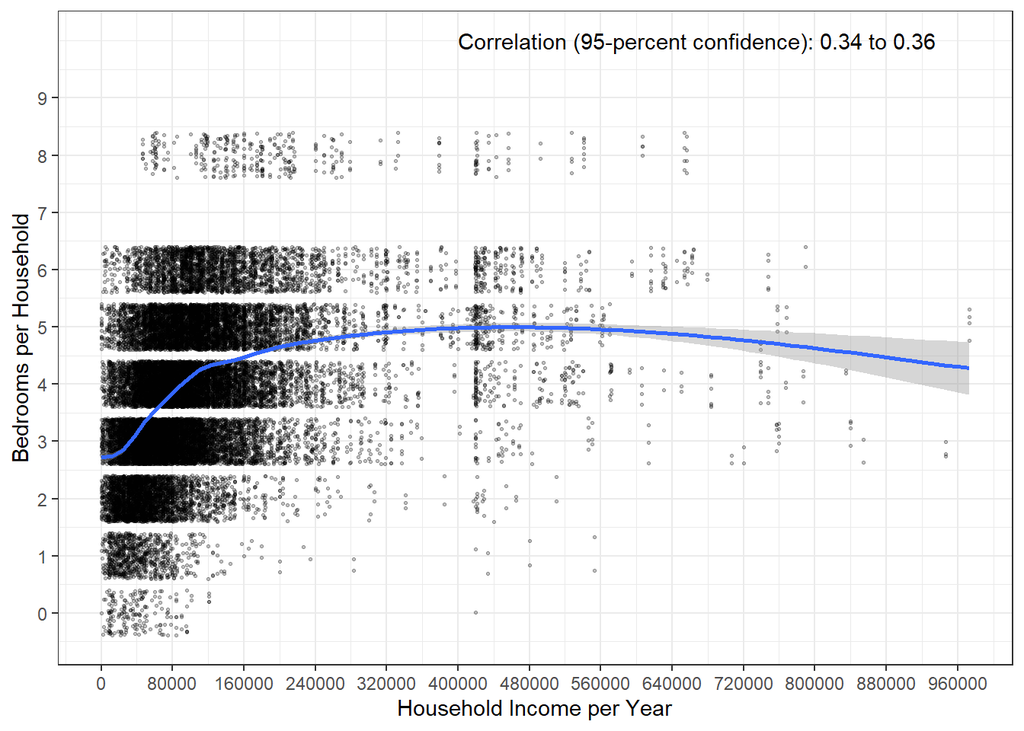

```r
ggplot(hh_data, aes(x = HINCP, y = BDSP)) +
  geom_point(size = 0.5, alpha = 0.25, position = "jitter") +
  geom_smooth() +
  theme_bw() +
  scale_x_continuous(name = "Household Income per Year",
                     breaks = seq(0,1000000, by = 80000)) +
  scale_y_continuous(name = "Bedrooms per Household",
                     breaks = seq(0, 9, by = 1)) +
  annotate(geom = "text", x = 400000, y = 10,
           label = paste("Correlation (95-percent confidence):",
                         prettyNum(correlationHINCPBDSP$conf.int[1], digits = 2),
                         "to",
                         prettyNum(correlationHINCPBDSP$conf.int[2], digits = 2)),
           hjust = 0)
```

Here is a graph showing the relationship between variables HINCP and NOC.

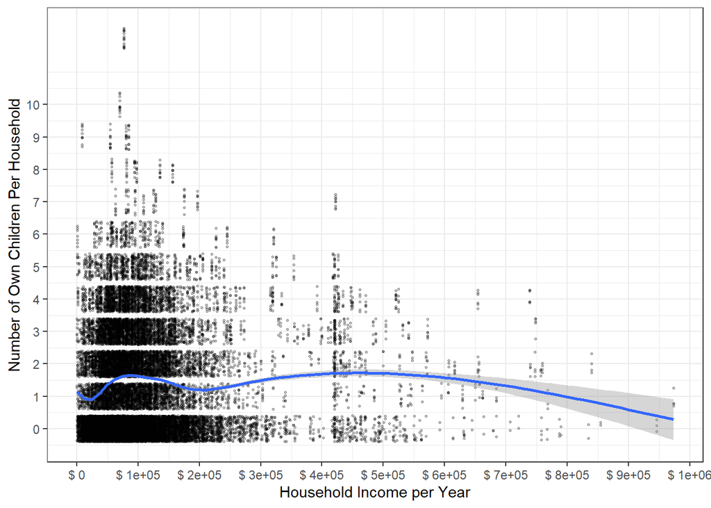

```r
ggplot(hh_data, aes(x = HINCP, y = NOC)) +
  geom_point(size = 0.5, alpha = 0.25, position = "jitter") +
  geom_smooth() +
  theme_bw() +
  scale_x_continuous(name = "Household Income per Year",
                     breaks = seq(0, 1000000, by = 100000),
                     labels = paste("$",
                                    prettyNum(seq(0, 1000000, by =100000),
                                              big.mark = ","))) +
  scale_y_continuous(name = "Number of Own Children Per Household",
                     breaks = seq(0, 10, by = 1))
```

```r
  annotate(geom = "text", x = 400000, y = 11,
           label = paste("Correlation (95-percent confidence):",
                         prettyNum(correlationHINCPNOC$conf.int[1], digits = 2),
                         "to",
                        prettyNum(correlationHINCPNOC$conf.int[2], digits = 2)),
           hjust = 0)
```

```
## mapping: x = ~x, y = ~y
## geom_text: na.rm = FALSE
## stat_identity: na.rm = FALSE
## position_identity
```

Here is a graph showing the relationship between variables NP and NOC.

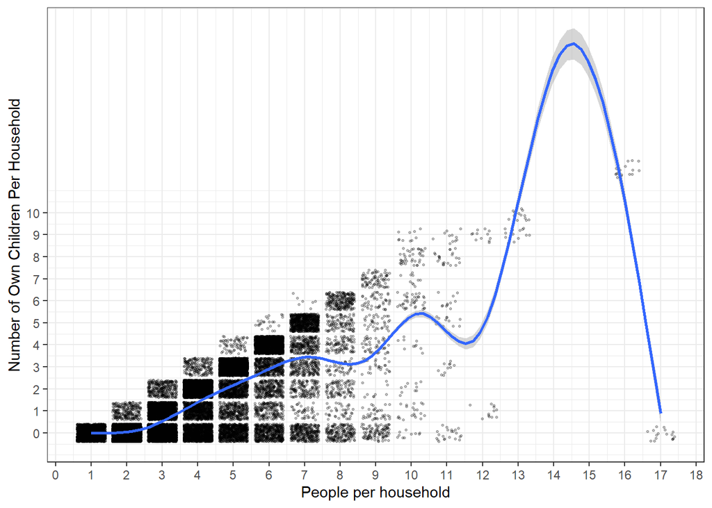

```r
ggplot(hh_data, aes(x = NP, y = NOC)) +
  geom_point(size = 0.5, alpha = 0.25, position = "jitter") +
  geom_smooth() +
  theme_bw() +
  scale_x_continuous(name = "People per household",
                     breaks = seq(0, 20, by = 1),
                     labels = paste(prettyNum(seq(0, 20, by =1),
                                              big.mark = ","))) +
  scale_y_continuous(name = "Number of Own Children Per Household",
                     breaks = seq(0, 10, by = 1))
```

```r
  annotate(geom = "text", x = 10, y = 8,
           label = paste("Correlation (95-percent confidence):",
                         prettyNum(correlationNPNOC$conf.int[1], digits = 2),
                         "to",
                        prettyNum(correlationNPNOC$conf.int[2], digits = 2)),
           hjust = 0)
```

```
## mapping: x = ~x, y = ~y
## geom_text: na.rm = FALSE
## stat_identity: na.rm = FALSE
## position_identity
```

Here is a graph showing the relationship between variables BDSP and NOC.

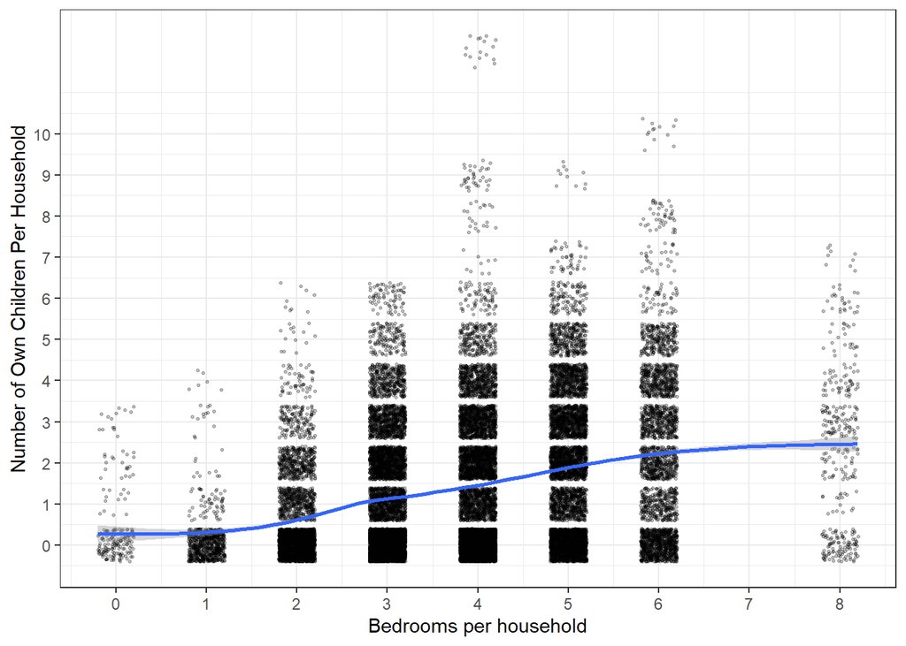

```r
ggplot(hh_data, aes(x = jitter(BDSP), y = NOC)) +
  geom_point(size = 0.5, alpha = 0.25, position = "jitter") +
  geom_smooth() +
  theme_bw() +
  scale_x_continuous(name = "Bedrooms per household",
                     breaks = seq(0, 20, by = 1),
                     labels = paste(prettyNum(seq(0, 20, by = 1),
                                              big.mark = ","))) +
  scale_y_continuous(name = "Number of Own Children Per Household",
                     breaks = seq(0, 10, by = 1))
```

Here is a graph showing the relationship between variables BDSP and NP.

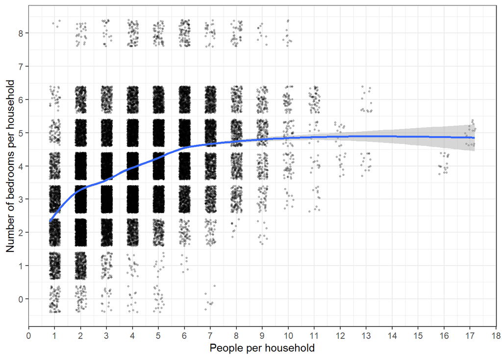

```r
ggplot(hh_data, aes(x = jitter(NP), y = BDSP)) +
  geom_point(size = 0.5, alpha = 0.25, position = "jitter") +
  geom_smooth() +
  theme_bw() +
  scale_x_continuous(name = "People per household",
                     breaks = seq(0, 20, by = 1),
                     labels = paste(prettyNum(seq(0, 20, by = 1),
                                              big.mark = ","))) +
  scale_y_continuous(name = "Number of bedrooms per household",
                     breaks = seq(0, 10, by = 1))
```

**continuous/categorical (3+ variables)**

1. bedrooms per household + access to internet: statistically significant
2. people per household + access to internet: statistically significant
3. own children in household + access to internet: statistically significant
4. household income + access to internet: statistically significant

```r
anova1 <- aov(HINCP ~ ACCESS_label, data = hh_data)
summary(anova1)
```

```
##                 Df    Sum Sq   Mean Sq F value Pr(>F)
## ACCESS_label     2 3.443e+12 1.721e+12   205.8 <2e-16 ***
## Residuals    30319 2.536e+14 8.366e+09
## ---
## Signif. codes:  0 '***' 0.001 '**' 0.01 '*' 0.05 '.' 0.1 ' ' 1
```

```r
anova2 <- aov(BDSP ~ ACCESS_label, data = hh_data)
summary(anova2)
```

```
##                 Df Sum Sq Mean Sq F value Pr(>F)
## ACCESS_label     2   2036  1018.1     570 <2e-16 ***
## Residuals    30319  54159     1.8
## ---
## Signif. codes:  0 '***' 0.001 '**' 0.01 '*' 0.05 '.' 0.1 ' ' 1
```

```r
anova3 <- aov(NP ~ ACCESS_label, data = hh_data)
summary(anova3)
```

```
##                 Df Sum Sq Mean Sq F value Pr(>F)
## ACCESS_label     2   2307    1154   286.2 <2e-16 ***
## Residuals    30319 122183       4
## ---
## Signif. codes:  0 '***' 0.001 '**' 0.01 '*' 0.05 '.' 0.1 ' ' 1
```

```r
anova4 <- aov(NOC ~ ACCESS_label, data = hh_data)
summary(anova4)
```

```
##                 Df Sum Sq Mean Sq F value Pr(>F)
## ACCESS_label     2   1070   535.2   188.3 <2e-16 ***
## Residuals    30319  86164     2.8
## ---
## Signif. codes:  0 '***' 0.001 '**' 0.01 '*' 0.05 '.' 0.1 ' ' 1
```

Here is a graph showing the relationship between internet access and household income. Although the graph is formatted poorly (sorry just did not have the time to fix it), those with no internet access have a markedly lower income than those who do access internet.

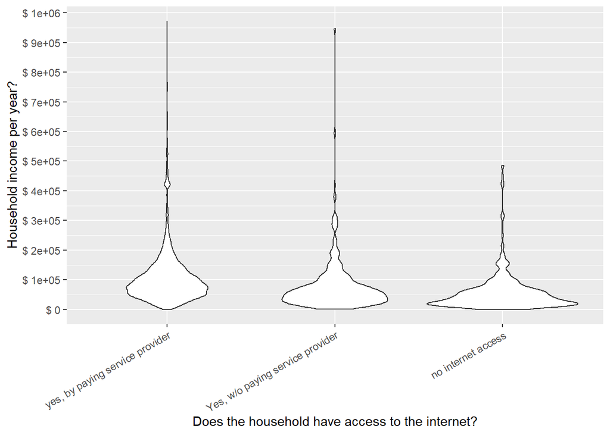

```r
ggplot(hh_data, aes(x = ACCESS, y = HINCP)) +
  geom_violin() +
  scale_x_discrete(name = "Does the household have access to the internet?",
                   labels = c("2"="Yes, w/o paying service provider", "1"="yes, by paying service provider", "3"="no internet access")) +
   scale_y_continuous(name = "Household income per year?",
                     breaks = seq(0, 1000000, by = 100000),
                     labels = paste("$",
                                    prettyNum(seq(0, 1000000, by = 100000),
                                              big.mark = ","))) +
                     theme(axis.text.x = element_text(angle = 30, hjust = 1))
```

**continuous/binary**

1. HINCP + LAPTOP: stasticially significant relationship - because p value and intervals both below 0
2. HINCP + SMARTPHONE: stasticially significant relationship - because p value and intervals both below 0
3. BDSP + LAPTOP: stasticially significant relationship - because p value and intervals both below 0
4. BDSP + SMARTPHONE: stasticially significant relationship - because p value and intervals both below 0
5. NP + LAPTOP: stasticially significant relationship - because p value and intervals both below 0
6. NP + SMARTPHONE: stasticially significant relationship - because p value and intervals both below 0
7. NOC + LAPTOP: stasticially significant relationship - because p value and intervals both below 0
8. NOC + SMARTPHONE: stasticially significant relationship - because p value and intervals both below 0

```r
difference1 = t.test(HINCP ~ LAPTOP == "1",
                    data = hh_data)
difference1
```

```
##
##  Welch Two Sample t-test
##
## data:  HINCP by LAPTOP == "1"
## t = -36.784, df = 3271.3, p-value < 2.2e-16
## alternative hypothesis: true difference in means is not equal to 0
## 95 percent confidence interval:
##  -53005.45 -47640.76
## sample estimates:
## mean in group FALSE  mean in group TRUE
##             59761.7            110084.8
```

```r
difference2 = t.test(HINCP ~ SMARTPHONE == "1",
                    data = hh_data)
difference2
```

```
##
##  Welch Two Sample t-test
##
## data:  HINCP by SMARTPHONE == "1"
## t = -21.907, df = 2063.4, p-value < 2.2e-16
## alternative hypothesis: true difference in means is not equal to 0
## 95 percent confidence interval:
##  -47991.07 -40104.73
## sample estimates:
## mean in group FALSE  mean in group TRUE
##            64818.59           108866.49
```

```r
difference3 = t.test(BDSP ~ LAPTOP == "1",
                    data = hh_data)
difference3
```

```
##
##  Welch Two Sample t-test
##
## data:  BDSP by LAPTOP == "1"
## t = -41.292, df = 2759, p-value < 2.2e-16
## alternative hypothesis: true difference in means is not equal to 0
## 95 percent confidence interval:
##  -1.151137 -1.046766
## sample estimates:
## mean in group FALSE  mean in group TRUE
##            2.847332            3.946283
```

```r
difference4 = t.test(BDSP ~ SMARTPHONE == "1",
                    data = hh_data)
difference4
```

```
##
##  Welch Two Sample t-test
##
## data:  BDSP by SMARTPHONE == "1"
## t = -26.307, df = 2023.8, p-value < 2.2e-16
## alternative hypothesis: true difference in means is not equal to 0
## 95 percent confidence interval:
##  -0.8907947 -0.7671964
## sample estimates:
## mean in group FALSE  mean in group TRUE
##            3.082910            3.911906
```

```r
difference5 = t.test(NP ~ LAPTOP == "1",
                    data = hh_data)
difference5
```

```
##
##  Welch Two Sample t-test
##
## data:  NP by LAPTOP == "1"
## t = -27.433, df = 2739.2, p-value < 2.2e-16
## alternative hypothesis: true difference in means is not equal to 0
## 95 percent confidence interval:
##  -1.199632 -1.039578
## sample estimates:
## mean in group FALSE  mean in group TRUE
##            3.007874            4.127479
```

```r
difference6 = t.test(NP ~ SMARTPHONE == "1",
                    data = hh_data)
difference6
```

```
##
##  Welch Two Sample t-test
##
## data:  NP by SMARTPHONE == "1"
## t = -35.926, df = 2062.4, p-value < 2.2e-16
## alternative hypothesis: true difference in means is not equal to 0
## 95 percent confidence interval:
##  -1.661085 -1.489122
## sample estimates:
## mean in group FALSE  mean in group TRUE
##            2.560068            4.135171
```

```r
difference7 = t.test(NOC ~ LAPTOP_label == "Yes",
                    data = hh_data)
difference7
```

```
##
##  Welch Two Sample t-test
##
## data:  NOC by LAPTOP_label == "Yes"
## t = -21.292, df = 2953, p-value < 2.2e-16
## alternative hypothesis: true difference in means is not equal to 0
## 95 percent confidence interval:
##  -0.6844659 -0.5690333
## sample estimates:
## mean in group FALSE  mean in group TRUE
##           0.8368329           1.4635825
```

```r
difference8 = t.test(NOC ~ SMARTPHONE_label == "Yes",
                    data = hh_data)
difference8
```

```
##
##  Welch Two Sample t-test
##
## data:  NOC by SMARTPHONE_label == "Yes"
## t = -42.538, df = 2456.7, p-value < 2.2e-16
## alternative hypothesis: true difference in means is not equal to 0
## 95 percent confidence interval:
##  -1.156282 -1.054374
## sample estimates:
## mean in group FALSE  mean in group TRUE
##           0.3756345           1.4809626
```

The following graphs show the relationship between laptop access and household income, then smartphone access and household income, respectively. As would likely be expected, those with lower incomes are less likely to have access to a laptop or smartphone in their household.

[figure not shown]

```r
ggplot(hh_data, aes(x = LAPTOP, y = HINCP)) +
  geom_violin() +
  scale_x_discrete(name = "Does someone in the household own a laptop?",
                   labels = c("No", "Yes")) +
   scale_y_continuous(name = "Household year income",
                     breaks = seq(0, 800000, by = 100000),
                     labels = paste("$",
                                    prettyNum(seq(0, 800000, by = 100000),
                                              big.mark = ",")))
```

[figure not shown]

```r
ggplot(hh_data, aes(x = SMARTPHONE, y = HINCP)) +
  geom_violin() +
  scale_x_discrete(name = "household yearly income",
                   labels = c("2"="No", "1"="Yes")) +
   scale_y_continuous((name = "bedrooms per household"),
                     (breaks = seq(0, 900000, by = 100000)),
                     labels = paste(prettyNum(seq(0, 900000, by = 100000),
                                              big.mark = ",")))+
    theme(axis.text.x = element_text(angle = 30, hjust = 1))
```

**categorical/categorical**

1. ACCESS + LAPTOP: statistically significant linear relationship
2. ACCESS + SMARTPHONE:statistically significant linear relationship
3. LAPTOP + SMARTPHONE: statistically significant linear relationship

```r
chi_sq1 <- chisq.test(hh_data$ACCESS, hh_data$LAPTOP_label == "Yes")
chi_sq1
```

```
##
##  Pearson's Chi-squared test
##
## data:  hh_data$ACCESS and hh_data$LAPTOP_label == "Yes"
## X-squared = 6833.3, df = 2, p-value < 2.2e-16
```

```r
chi_sq2 <- chisq.test(hh_data$ACCESS, hh_data$SMARTPHONE_label == "Yes")
chi_sq2
```

```
##
##  Pearson's Chi-squared test
##
## data:  hh_data$ACCESS and hh_data$SMARTPHONE_label == "Yes"
## X-squared = 4458.2, df = 2, p-value < 2.2e-16
```

```r
chi_sq3 <- chisq.test(hh_data$LAPTOP, hh_data$SMARTPHONE_label == "Yes")
chi_sq3
```

```
##
##  Pearson's Chi-squared test with Yates' continuity correction
##
## data:  hh_data$LAPTOP and hh_data$SMARTPHONE_label == "Yes"
## X-squared = 2523, df = 1, p-value < 2.2e-16
```